# Feature Extraction (Bag of Words)

[return to overview page]

A surprising amount can be learned by simplying analyzing the individual words in a statement. Several of the previous features we extracted (parts of speech, sentiment) were indeed inferred through analysis of individual words. We mapped, for example, from individual words onto emotions (e.g. “excited” -> positive) and used this to infer the overall sentiment of a statement (by summing across the emotions associated with each word in a statement). Or, we mapped from individual words to parts of speech (e.g. “ate” -> verb). However, in each of these applications, in a sense, we were loosing information, as we were mapping from granular, individual words to larger categories (sentiment, parts of speech). Ultimately, a great deal of information lies in these words themselves. Extracting these individual words will be the focus here. Sometimes, this is called a “bag of words” approach, as we are simply counting up and examining the occurence of individual words, with no regard for things like their order (Bag-of-words model, 2019).

In the previous sections, we extracted features that were based, at least somewhat, on previous knowledge or theories (e.g. people may be more anxious when they lie, so statement sentiment might be a useful feature to extract). In this case, our approach is more atheoretical. We are simply assuming that words are a rich source of data and as a result might provide predictive value for detecting lies. This may allow us to discover associations that we might have predicted or had any inkling of beforehand. Of course, there is the obvious (and well-justified) worry that this is just a means of dredging the data for some results – and with enough dredging we are bound to find something (Simmons, Nelson, & Simonsohn, 2011). However, so long as we careful that these unpredicted associations are robust and replicable, which will try to ensure through repeated out of sample prediction procedures, this offers an avenue by which we may greatly increase our predictive ability.

Thus, in this final section, I will focus on extracting the feature central to a great deal of current social scientific text-analysis – counts of individual word frequencies. More specifically, I will create the canonical data object used in social scientific text analysis – the “document-term matrix”, a matrix where there is a row for each document (in this data set each of the 5004 statements is a “document”), and there is a column for each possible word, and the values in each cell represents the number of times that a particular word occured in a particular document.

Most text-analysis techniques then manipulate this object in some way to reduce its size and complexity. Some common manipulations include:

- tf-idf (a simple way to reduce the weight of words that occur commonly across documents)
- latent semantic analysis (a method for grouping and finding meaning similarity in words)
- principle component analysis (another dimension reduction technique, that can be used to find underlying similarities between words)

Many of these techniques are often especially useful in the context of “topic modeling”, where the goal is to find the major topics across a series of documents (e.g. by examining the ways in which individual words in newspaper articles cluster together (e.g. “game”, “ball”, “win” v. “election”, “leader”, “vote”), we can infer the topic of the article (e.g. sports v. politics). However, in this analysis, the central aim is not to discover different topics, but simply to see if certain individual words can help us in predicting the truthfulness of a statement.

# Packages

Again, I will start by loading relevant packages.

```r
library(tidyverse) # cleaning and visualization
library(quanteda) # text analysis
library(tidytext) # text analysis
library(ggthemes)
```

# Load Data

I will load the most recent version of the cleaned statements, which comes from Feature Extraction. (Note, we created a more recent object, recording the complexity of each statement. However, we will not be using that object right now.)

```r
# this loads: stats_clean (a data-frame of out cleaned statements)
load("stats_clean.Rda")
```

# Example (Generating Bags of Words and the Document-Term Matrix)

Most simply, our goal is to examine all the unique words that occur across all statements and then count up the number of times that each of these words occurs in each statement. Through looking at these “bags of words”, we will create our the document-term matrix.

## Example (Statements)

As before, I will begin with a simple example.

Imagine we have a set of 3 statements, where people are describing their interests.

- “I like cars. I like fast cars, and slow cars, and big cars.”
- “I like to drink. I really like to drink tequila and beer.”
- “I like to eat. My favorite food to eat is pizza.”

```r
# Create df, with statements.
example_df <-
  data.frame(statement = c("I like cars. I like fast cars, and slow cars, and big cars.",
                           "I like to drink. I really like to drink tequila and beer.",
                           "I like to eat. My favorite food to eat is pizza."),
             stat_num = c(1, 2, 3)) %>%
  mutate(statement = as.character(statement))

# Print df
print(example_df)
```

```
##                                                     statement stat_num
## 1 I like cars. I like fast cars, and slow cars, and big cars.        1
## 2   I like to drink. I really like to drink tequila and beer.        2
## 3            I like to eat. My favorite food to eat is pizza.        3
```

## Example (Unique Words)

One thing we can do with these statements is examine how many unique words there are across all of them. When we count, we see that there are 18 unique words across these three statements. Thus, our final document-term matrix will have 3 rows (one for each statement), and 18 columns (one for each unique word that could have occurred in that statement; not that not all words occur in all statements; in fact, most documents, most words don’t occur in most documents; rather a few words account for most of text; a phenomenon captured by Zipf’s law; Silge, & Robinson, 2016, Chapter 3, Section 2).

```r
# unique words across all 3 statements
num_unique <-
  ntype(x = paste(unlist(example_df$statement),
                collapse = " "),
        remove_punct = TRUE)

# Print
print(paste("Number of unique words: ", num_unique))
```

```
## [1] "Number of unique words:  18"
```

## Example (Overall Word Frequencies)

Here we can see how frequently each word was “said” across *all* statements. As in a high school cateferia, the most common word is “like”. Our next step is to count how frequently each word was “said” in each individual statement. With this, we will be creating our document-term matrix.

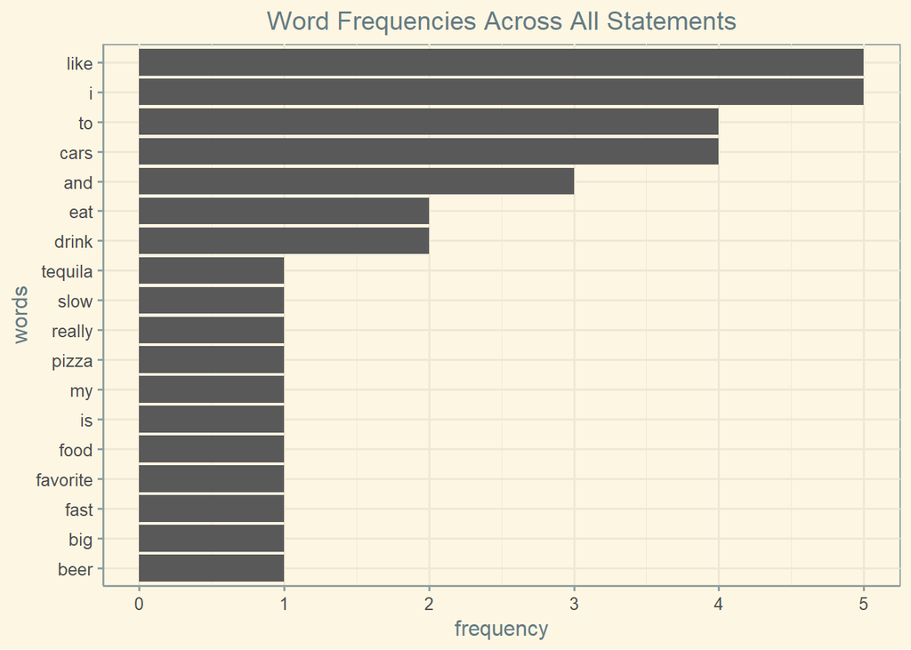

```r
example_df %>%
  unnest_tokens(input = statement,
              output = word,
              token = "words") %>%
  group_by(word) %>%
  dplyr::summarize(n = n()) %>%
  arrange(desc(n)) %>%
  ggplot(aes(x = reorder(word,
                         n),
            y = n)) +
  geom_col() +
  coord_flip() +
  labs(title = "Word Frequencies Across All Statements",
       x = "words",
       y = "frequency") +
  theme_solarized() +
  theme(plot.title = element_text(hjust = 0.5))
```

## Example (Document-Term Matrix)

Below, I’ve created the document-term matrix, for our simple corpus of three statements. In it, we have a row for each statement, and a column for each of the unique words that has appeared throughout the entire text. And each cell represents a count for many times a given word occurred in a given statment. (I appended the prefix “wrd_” before each word; words themselves are capitalized; this was done to ease readability in later analyses.) For example, we see that the word “and” occured twice in the first statement, once in the second statement, and not at all in the third statement. Each individual row here can be thought of as a “bag of words” and all the bags together comprise the document-term matrix.

```r
# create document-term matrix
example_dtm <-
  example_df %>%
  unnest_tokens(input = statement,
              output = word,
              token = "words") %>%
  mutate(word = toupper(word)) %>%
  group_by(stat_num, word) %>%
  dplyr::summarize(n = n()) %>%
  spread(key = word,
         value = n,
         fill = 0)

# rename all words to have a prefix before the word
old_names <- colnames(example_dtm)[2:ncol(example_dtm)]
new_names <- paste("wrd_", old_names, sep = "")
colnames(example_dtm)[2:ncol(example_dtm)] <- new_names
rm(old_names, new_names) # delete so i can just reuse these variable names later

# print document-term matrix
example_dtm
```

| stat_num | wrd_AND | wrd_BEER | wrd_BIG | wrd_CARS | wrd_DRINK | wrd_EAT | wrd_FAST | wrd_FAVORITE | wrd_FOOD | wrd_I | wrd_IS | wrd_LIKE | wrd_MY | wrd_PIZZA | wrd_REALLY | wrd_SLOW | wrd_TEQUILA | wrd_TO |
| --- | --- | --- | --- | --- | --- | --- | --- | --- | --- | --- | --- | --- | --- | --- | --- | --- | --- | --- |
| 1 | 2 | 0 | 1 | 4 | 0 | 0 | 1 | 0 | 0 | 2 | 0 | 2 | 0 | 0 | 0 | 1 | 0 | 0 |
| 2 | 1 | 1 | 0 | 0 | 2 | 0 | 0 | 0 | 0 | 2 | 0 | 2 | 0 | 0 | 1 | 0 | 1 | 2 |
| 3 | 0 | 0 | 0 | 0 | 0 | 2 | 0 | 1 | 1 | 1 | 1 | 1 | 1 | 1 | 0 | 0 | 0 | 2 |

# Full Dataset (Generating the Document-Term Matrix)

And now the let’s do the same for the full set of statements.

First, let’s just get a sense of the properties and distributions of the words as they occur across all statements in the dataset.

## Full Dataset (Total Number of Words and Unique Words)

As we can see, there are about 280,000 total words and 11,000 unique words across the full set of statements.

```r
data.frame(n = c(ntype(x = paste(unlist(stats_clean$statement),
                                 collapse = " "),
                       remove_punct = TRUE),
                 ntoken(x = paste(unlist(stats_clean$statement),
                                   collapse = " "),
                         remove_punct = TRUE)),
           count_of = c("unique words", "total words")) %>%
  select(count_of, n) %>%
  arrange(desc(n))
```

| count_of | n |
| --- | --- |
| total words | 282182 |
| unique words | 11423 |

## Full Dataset (Most Frequent Words)

And now let’s look at what are the top 50 most common words in our dataset. As we can see, the most frequently occurring word is “i”, with well over 15,000 occurrences. (It might be tempting to call our subjects egocentric, but all questions asked participants about themselves – what they did yesterday, what their regrets are, etc. – so it’s perhaps unsurprising that the most common word was one that focused on themselves.) The next most common words are “and”, “to”, and “a”, common conjunctions, prepositions, and articles used to glue together sentences.

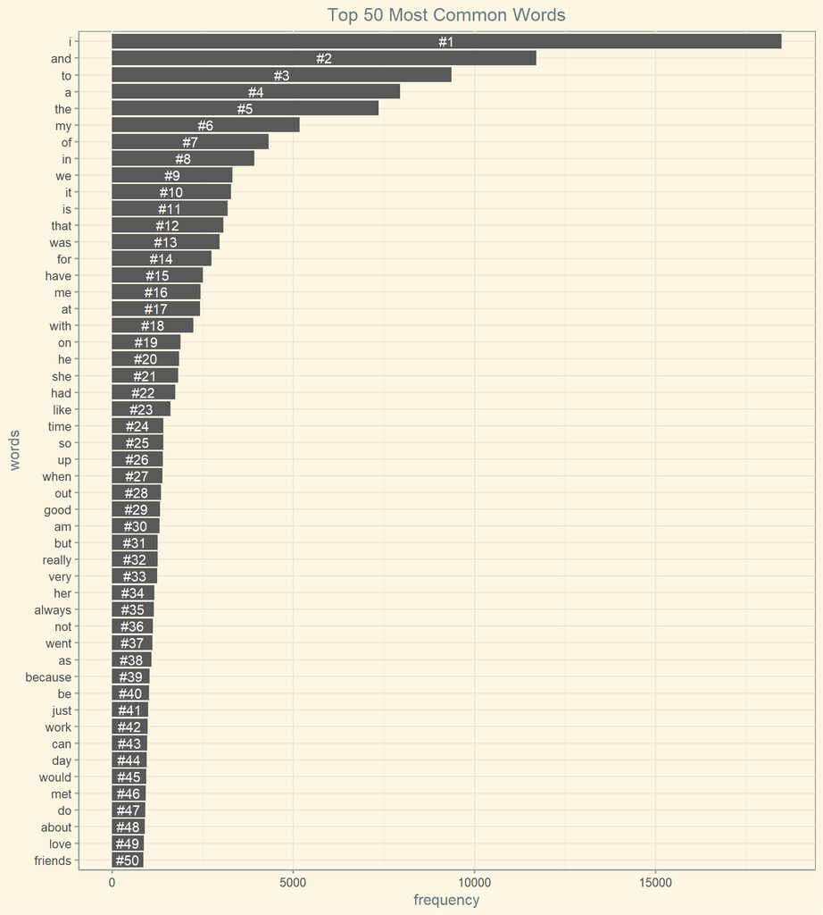

```r
# create data frame to store count of number of times each word occurs
word_freq <-
  stats_clean %>%
  select(stat_id,
         statement) %>%
  unnest_tokens(input = statement,
                output = word,
                token = "words",
                strip_punct = TRUE) %>%
  group_by(word) %>%
  dplyr::summarize(n = n()) %>%
  arrange(desc(n)) %>%
  dplyr::mutate(rank = row_number())

# plot the results
word_freq %>%
  filter(rank <= 50) %>%
  ggplot(aes(x = reorder(word, n),
             y = n)) +
  geom_col() +
  geom_text(aes(label = paste("#", rank, sep = "")),
            position = position_stack(vjust = 0.5),
            color = "white") +
  coord_flip() +
  labs(title = "Top 50 Most Common Words",
       x = "words",
       y = "frequency") +
  theme_solarized() +
  theme(plot.title = element_text(hjust = 0.5))
```

## Full Dataset (Zipf’s Law)

And now let’s look at the distribution of those words. A common empirical fact across many types of text is that a small set of words account for most of the text in a given corpus. In fact, Zipf’s Law describes the mathematical relationship between word rank and word frequency. I display a graph below which demonstrates that this relationship holds in our dataset as well. A few unique words account for most of the total words here too. As highlighted by the red dotted lines, the top 5 words account for almost 20% of all words (19.4% to be more precise). And more than 50% of the words are accounted for by only the top 57 (out of over 11,000 unique) words. (Note the spacing of the x-axis is log (base 10) scaled.)

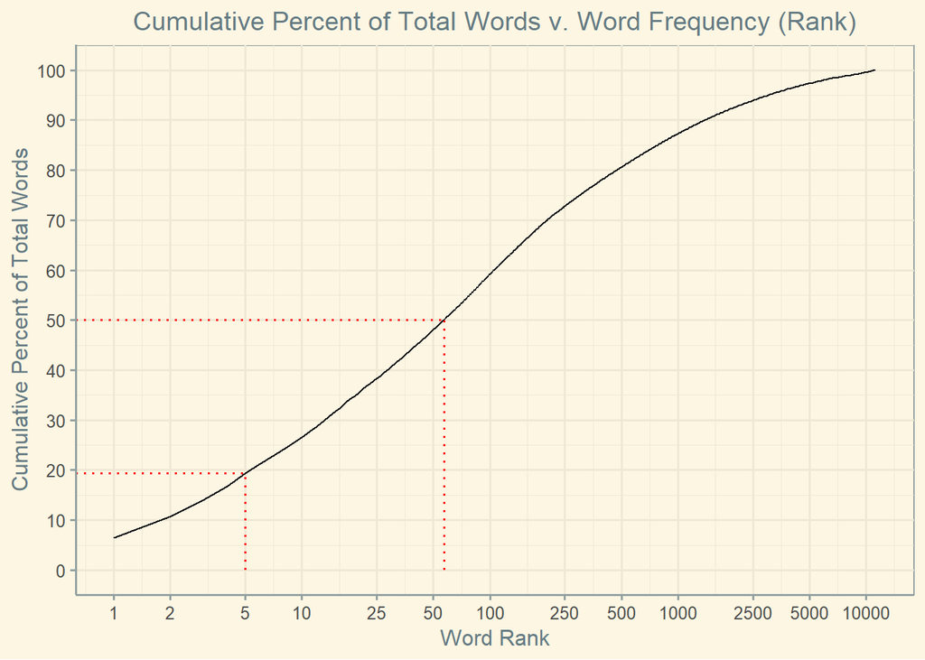

```r
word_freq %>%
  mutate(prop = n / sum(n),
         cum_prop = cumsum(n) / sum(n)) %>%
  ggplot(aes(x = rank,
             y = round(cum_prop * 100, 1))) +
  geom_line() +
  geom_segment(aes(x = 5, xend = 5, y = 0, yend = 19.4),
               color = "red",
               linetype = "dotted",
               size = 0.7) +
  geom_segment(aes(x = 0, xend = 5, y = 19.4, yend = 19.4),
               color = "red",
               linetype = "dotted",
               size = 0.7) +
  geom_segment(aes(x = 57, xend = 57, y = 0, yend = 50),
               color = "red",
               linetype = "dotted",
               size = 0.7) +
    geom_segment(aes(x = 0, xend = 57, y = 50, yend = 50),
               color = "red",
               linetype = "dotted",
               size = 0.7) +
  scale_y_continuous(breaks = seq(from = 0,
                                  to = 100,
                                  by = 10)) +
  scale_x_continuous(breaks = c(1, 2, 5, 10, 25, 50, 100, 250, 500, 1000, 2500, 5000, 10000),
                     trans = "log10") +
  labs(title = "Cumulative Percent of Total Words v. Word Frequency (Rank)",
       y = "Cumulative Percent of Total Words",
       x = "Word Rank") +
  theme_solarized() +
  theme(plot.title = element_text(hjust = 0.5))
```

## Full Dataset (Document-Term Matrix)

And finally, now let’s actually generate the document-term matrix for the full dataset.

```r
# create document-term matrix
start_time <- Sys.time()
stats_dtm <-
  stats_clean %>%
  select(stat_id, statement) %>%
  unnest_tokens(input = statement,
              output = word,
              token = "words",
              strip_punct = TRUE) %>%
  mutate(word = toupper(word)) %>%
  group_by(stat_id, word) %>%
  dplyr::summarize(n = n()) %>%
  spread(key = word,
         value = n,
         fill = 0)
total_time <- Sys.time() - start_time # 12-15 seconds (so: quick)

# rename all words to have a prefix before the word
old_names <- colnames(stats_dtm)[2:ncol(stats_dtm)]
new_names <- paste("wrd_", old_names, sep = "")
colnames(stats_dtm)[2:ncol(stats_dtm)] <- new_names


# print document-term matrix
stats_dtm[, 1:7]
```

| stat_id | wrd_00 | wrd_00AM | wrd_1 | wrd_1,107 | wrd_1;1 | wrd_1;10 |
| --- | --- | --- | --- | --- | --- | --- |
| 1 | 0 | 0 | 0 | 0 | 0 | 0 |
| 2 | 0 | 0 | 0 | 0 | 0 | 0 |
| 3 | 0 | 0 | 0 | 0 | 0 | 0 |
| 4 | 0 | 0 | 0 | 0 | 0 | 0 |
| 5 | 0 | 0 | 0 | 0 | 0 | 0 |
| 6 | 0 | 0 | 0 | 0 | 0 | 0 |
| 7 | 0 | 0 | 0 | 0 | 0 | 0 |
| 8 | 0 | 0 | 0 | 0 | 0 | 0 |
| 9 | 0 | 0 | 0 | 0 | 0 | 0 |
| 10 | 0 | 0 | 0 | 0 | 0 | 0 |

[output cut: 4994 more lines]

## Full Dataset (Size)

As we can see, the document-term matrix for the full data set is a massive object. It has over 56 million cells! (comprised from over 5000 rows and over 11,000 columns).

```r
# dimensions of dtm
dim(stats_dtm)
```

```
## [1]  5004 11251
```

```r
# cols slightly mismatch # unique words from before
# (I believe might be due to difference between quanteda and tidytext counting)

# total number of cells
prod(dim(stats_dtm))
```

```
## [1] 56300004
```

Full Dataset (Mini Document-Term Matrices)

The massive size of this matrix will make modeling difficult as it will greatly increase computation time. As mentioned before, there are various techniques to reduce the size and dimensionality of this document. One solution that people use for example is to simply run a PCA on this matrix and extract “core” factors that seem account for covariation among words. Other methods include techniques like tf-idf, which discounts more frequntly occuring words. I don’t prefer either of these solutions here. PCA reduces interpretability as words will eliminated in prediction, and predictions will simply be made from the various PCA “factors”. Meanwhile, tf-df downweights commonly occuring words, which is often useful when trying to infer topics, but will be detrimental here, as common words and parts of speech are often the most useful for inferring psychological states and characteristics. Indeed, this is the central mantra of James Pennebaker’s main research lines on natural language and psychology – which focus on those frequently occuring parts of speech.

I will thus employ a very simple heuristic solution. I will create “mini” document-term matrices that only have columns for the very most frequently occuring words. Specifically, I will create 4 “mini” document-term matrices – one with columns only for the top 100 most prevalent words, one with columns only for the top 50 most prevalent words, another with the top 25 words, and a final fourth one with top 10 words. This has the advantage of being easy to implement, easy to interpret (in analysis), and further eases prediction as frequently occuring words will have observations for most statements (e.g. uncommon words like “alligator”, which are only said by one person, will be eliminated and what will remain is words used by most people).

To make these mini document-term matrices, we’ll first need to make an object that ranks words by their frequency.

```r
# note this isn't actually the same as the word_freq object, which was counted
# with the ntokens() functions from the quanteda package. Further, we are going
# append the prefix "wrd" in front of each word, for later matching with column names.
uniq_words <-
  stats_clean %>%
  select(stat_id, statement) %>%
  unnest_tokens(input = statement,
              output = word,
              token = "words",
              strip_punct = TRUE) %>%
  mutate(word = toupper(word)) %>%
  group_by(word) %>%
  dplyr::summarize(n = n()) %>%
  arrange(desc(n)) %>%
  dplyr::mutate(rank = row_number()) %>%
  dplyr::mutate(word = paste("wrd_", word, sep = "")) %>%
  select(word, rank, n)

# print the outcome
uniq_words
```

| word | rank | n |
| --- | --- | --- |
| wrd_I | 1 | 18485 |
| wrd_AND | 2 | 11711 |
| wrd_TO | 3 | 9375 |
| wrd_A | 4 | 7953 |
| wrd_THE | 5 | 7359 |
| wrd_MY | 6 | 5173 |
| wrd_OF | 7 | 4330 |
| wrd_IN | 8 | 3934 |
| wrd_WE | 9 | 3325 |
| wrd_IT | 10 | 3281 |

[output cut: 9990 more lines]

From this, we can then create the four mini document-term matrices, with the only columns for the 100, 50, 25, and 10 most popular words.

```r
# get the names (with "wrd" prefix) of common words
top100 <- subset(uniq_words, rank <= 100)$word
top50 <-subset(uniq_words, rank <= 50)$word
top25 <- subset(uniq_words, rank <= 25)$word
top10 <- subset(uniq_words, rank <= 10)$word

# create objects
stats_dtm_100 <- subset(stats_dtm, select = c("stat_id", top100))
stats_dtm_50 <- subset(stats_dtm, select = c("stat_id", top50))
stats_dtm_25 <- subset(stats_dtm, select = c("stat_id", top25))
stats_dtm_10 <- subset(stats_dtm, select = c("stat_id", top10))
```

# Save

Finally, let’s save the full document-term matrix and the mini document-term matrices we created.

```r
# Save all objects
save(stats_dtm,
     stats_dtm_100,
     stats_dtm_50,
     stats_dtm_25,
     stats_dtm_10,
     file = "stats_words.Rda")

# Remove stats_clean from global environment
rm(stats_clean)
```

# Citations

- Bag-of-words model. (2019). In Wikipedia. Retrieved from https://en.wikipedia.org/w/index.php?title=Bag-of-words_model&oldid=894989930
- Silge, J., & Robinson, D. (2016). tidytext: Text mining and analysis using tidy data principles in r. The Journal of Open Source Software, 1(3), 37.
- Simmons, J. P., Nelson, L. D., & Simonsohn, U. (2011). False-positive psychology: Undisclosed flexibility in data collection and analysis allows presenting anything as significant. Psychological Science, 22(11), 1359-1366.